# 08_angle_conversions

## 08_angle_conversions

#### Question

1. For each diagram below, a circle is sliced into congruent sectors. An angle, which subtends an integer count of the sectors, is indicated by an circular arc near the center of the circle. You will determine the measure of the angle using degrees, radians, and (fractions of) turns. All radian measures will be expressed in exact form, as a fraction of $\pi$. All fractions will be shown in [reduced form](https://en.wikipedia.org/wiki/Irreducible_fraction), using improper fractions instead of mixed numbers.

   Unlike temperature, where Fahrenheit and Celsius disagree on 0, all three units of angle measure agree on 0. All three measures grow linearly with arc length of a unit circle, so conversions are simple proportions, and the conversion factors can be expressed with the following equivalences.

   $$360^{\circ}~=~2\pi \text{ radians}~=~1\text{ turn}$$

   **Express the following angles using degrees, radians, and turns.**

### Circle 1

   - The circle below is cut into 4 congruent sectors. The central angle, $\theta$ (theta), subtends 3 of the sectors.

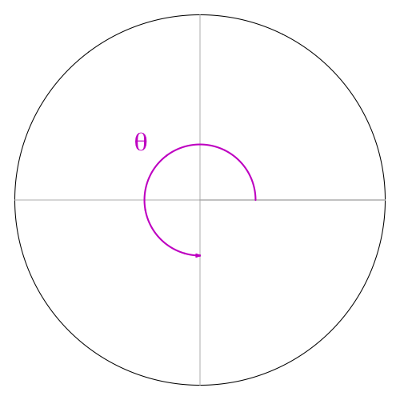

   - The angle is degrees.
   - The angle is $\pi\bigg/$ radians.
   - As a decimal approximation, the angle is radians.
   - The angle is $\bigg/$ turns.
   - As a decimal, the angle is turns.

### Circle 2

   - The circle below is cut into 10 congruent sectors. The central angle, $\phi$ (phi), subtends 2 of the sectors.

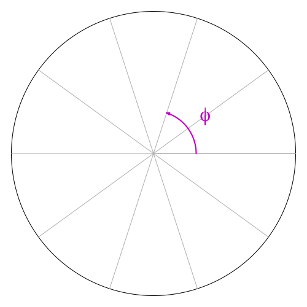

   - The angle is degrees.
   - The angle is $\pi\bigg/$ radians.
   - As a decimal approximation, the angle is radians.
   - The angle is $\bigg/$ turns.
   - As a decimal, the angle is turns.

### Circle 3

   - The circle below is cut into 24 congruent sectors. The central angle, $\omega$ (omega), subtends 19 of the sectors.

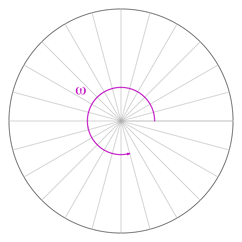

   - The angle is degrees.
   - The angle is $\pi\bigg/$ radians.
   - As a decimal approximation, the angle is radians.
   - The angle is $\bigg/$ turns.
   - As a decimal, the angle is turns.

### Circle 4

   - The circle below is cut into 6 congruent sectors. The central angle, $\psi$ (psi), subtends 1 of the sectors.

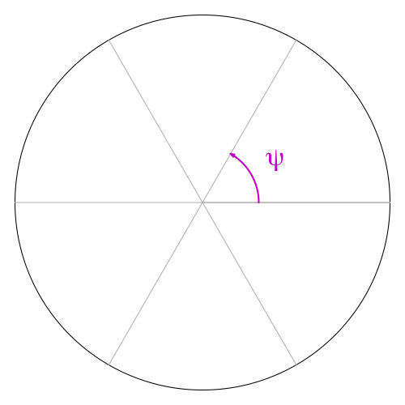

   - The angle is degrees.
   - The angle is $\pi\bigg/$ radians.
   - As a decimal approximation, the angle is radians.
   - The angle is $\bigg/$ turns.
   - As a decimal, the angle is turns.

### Circle 5

   - The circle below is cut into 18 congruent sectors. The central angle, $\beta$ (beta), subtends 10 of the sectors.

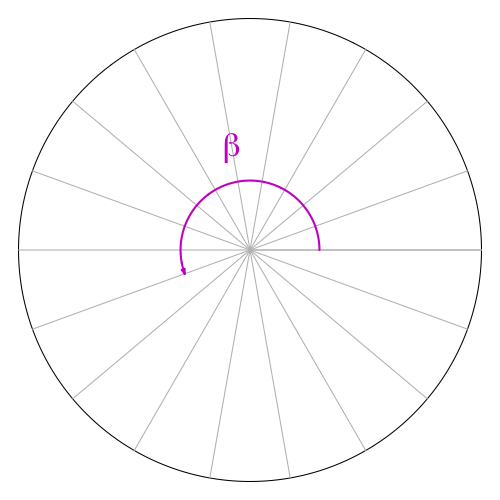

   - The angle is degrees.
   - The angle is $\pi\bigg/$ radians.
   - As a decimal approximation, the angle is radians.
   - The angle is $\bigg/$ turns.
   - As a decimal, the angle is turns.

#### Solution

#### Question

2. For each diagram below, a circle is sliced into congruent sectors. An angle, which subtends an integer count of the sectors, is indicated by an circular arc near the center of the circle. You will determine the measure of the angle using degrees, radians, and (fractions of) turns. All radian measures will be expressed in exact form, as a fraction of $\pi$. All fractions will be shown in [reduced form](https://en.wikipedia.org/wiki/Irreducible_fraction), using improper fractions instead of mixed numbers.

   Unlike temperature, where Fahrenheit and Celsius disagree on 0, all three units of angle measure agree on 0. All three measures grow linearly with arc length of a unit circle, so conversions are simple proportions, and the conversion factors can be expressed with the following equivalences.

   $$360^{\circ}~=~2\pi \text{ radians}~=~1\text{ turn}$$

   **Express the following angles using degrees, radians, and turns.**

### Circle 1

   - The circle below is cut into 20 congruent sectors. The central angle, $\theta$ (theta), subtends 12 of the sectors.

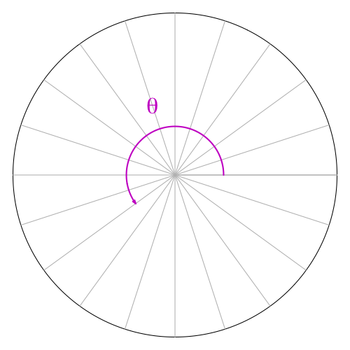

   - The angle is degrees.
   - The angle is $\pi\bigg/$ radians.
   - As a decimal approximation, the angle is radians.
   - The angle is $\bigg/$ turns.
   - As a decimal, the angle is turns.

### Circle 2

   - The circle below is cut into 10 congruent sectors. The central angle, $\phi$ (phi), subtends 9 of the sectors.

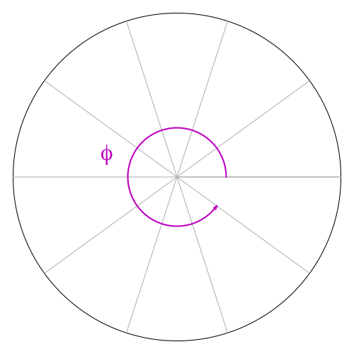

   - The angle is degrees.
   - The angle is $\pi\bigg/$ radians.
   - As a decimal approximation, the angle is radians.
   - The angle is $\bigg/$ turns.
   - As a decimal, the angle is turns.

### Circle 3

   - The circle below is cut into 24 congruent sectors. The central angle, $\omega$ (omega), subtends 23 of the sectors.

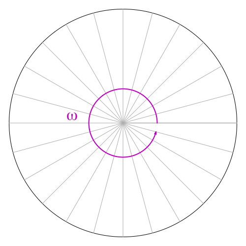

   - The angle is degrees.
   - The angle is $\pi\bigg/$ radians.
   - As a decimal approximation, the angle is radians.
   - The angle is $\bigg/$ turns.
   - As a decimal, the angle is turns.

### Circle 4

   - The circle below is cut into 18 congruent sectors. The central angle, $\psi$ (psi), subtends 6 of the sectors.

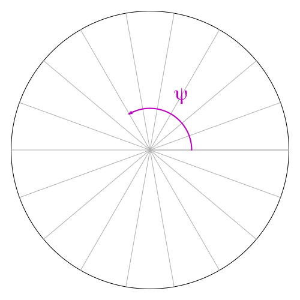

   - The angle is degrees.
   - The angle is $\pi\bigg/$ radians.
   - As a decimal approximation, the angle is radians.
   - The angle is $\bigg/$ turns.
   - As a decimal, the angle is turns.

### Circle 5

   - The circle below is cut into 6 congruent sectors. The central angle, $\beta$ (beta), subtends 1 of the sectors.

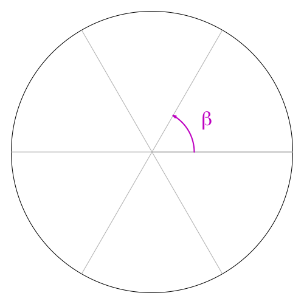

   - The angle is degrees.
   - The angle is $\pi\bigg/$ radians.
   - As a decimal approximation, the angle is radians.
   - The angle is $\bigg/$ turns.
   - As a decimal, the angle is turns.

#### Solution

#### Question

3. For each diagram below, a circle is sliced into congruent sectors. An angle, which subtends an integer count of the sectors, is indicated by an circular arc near the center of the circle. You will determine the measure of the angle using degrees, radians, and (fractions of) turns. All radian measures will be expressed in exact form, as a fraction of $\pi$. All fractions will be shown in [reduced form](https://en.wikipedia.org/wiki/Irreducible_fraction), using improper fractions instead of mixed numbers.

   Unlike temperature, where Fahrenheit and Celsius disagree on 0, all three units of angle measure agree on 0. All three measures grow linearly with arc length of a unit circle, so conversions are simple proportions, and the conversion factors can be expressed with the following equivalences.

   $$360^{\circ}~=~2\pi \text{ radians}~=~1\text{ turn}$$

   **Express the following angles using degrees, radians, and turns.**

### Circle 1

   - The circle below is cut into 10 congruent sectors. The central angle, $\theta$ (theta), subtends 8 of the sectors.

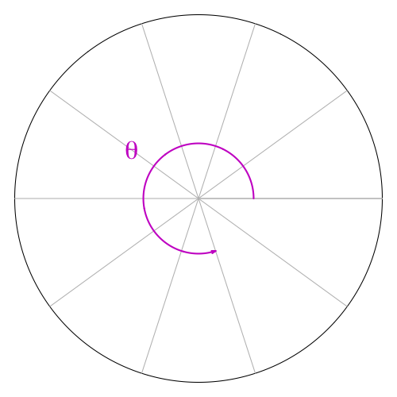

   - The angle is degrees.
   - The angle is $\pi\bigg/$ radians.
   - As a decimal approximation, the angle is radians.
   - The angle is $\bigg/$ turns.
   - As a decimal, the angle is turns.

### Circle 2

   - The circle below is cut into 18 congruent sectors. The central angle, $\phi$ (phi), subtends 16 of the sectors.

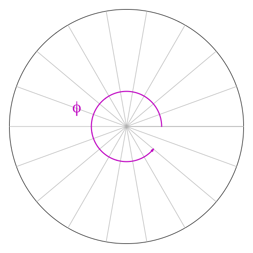

   - The angle is degrees.
   - The angle is $\pi\bigg/$ radians.
   - As a decimal approximation, the angle is radians.
   - The angle is $\bigg/$ turns.
   - As a decimal, the angle is turns.

### Circle 3

   - The circle below is cut into 8 congruent sectors. The central angle, $\omega$ (omega), subtends 1 of the sectors.

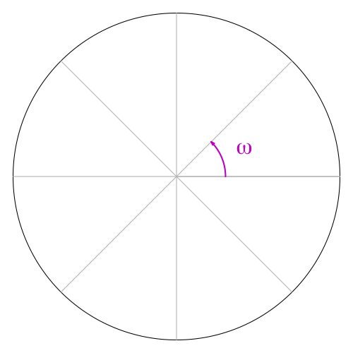

   - The angle is degrees.
   - The angle is $\pi\bigg/$ radians.
   - As a decimal approximation, the angle is radians.
   - The angle is $\bigg/$ turns.
   - As a decimal, the angle is turns.

### Circle 4

   - The circle below is cut into 4 congruent sectors. The central angle, $\psi$ (psi), subtends 3 of the sectors.

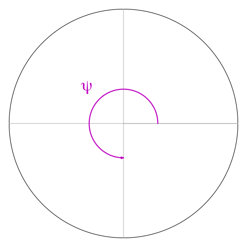

   - The angle is degrees.
   - The angle is $\pi\bigg/$ radians.
   - As a decimal approximation, the angle is radians.
   - The angle is $\bigg/$ turns.
   - As a decimal, the angle is turns.

### Circle 5

   - The circle below is cut into 24 congruent sectors. The central angle, $\beta$ (beta), subtends 14 of the sectors.

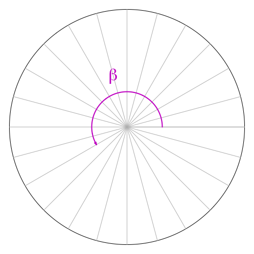

   - The angle is degrees.
   - The angle is $\pi\bigg/$ radians.
   - As a decimal approximation, the angle is radians.
   - The angle is $\bigg/$ turns.
   - As a decimal, the angle is turns.

#### Solution

#### Question

4. For each diagram below, a circle is sliced into congruent sectors. An angle, which subtends an integer count of the sectors, is indicated by an circular arc near the center of the circle. You will determine the measure of the angle using degrees, radians, and (fractions of) turns. All radian measures will be expressed in exact form, as a fraction of $\pi$. All fractions will be shown in [reduced form](https://en.wikipedia.org/wiki/Irreducible_fraction), using improper fractions instead of mixed numbers.

   Unlike temperature, where Fahrenheit and Celsius disagree on 0, all three units of angle measure agree on 0. All three measures grow linearly with arc length of a unit circle, so conversions are simple proportions, and the conversion factors can be expressed with the following equivalences.

   $$360^{\circ}~=~2\pi \text{ radians}~=~1\text{ turn}$$

   **Express the following angles using degrees, radians, and turns.**

### Circle 1

   - The circle below is cut into 10 congruent sectors. The central angle, $\theta$ (theta), subtends 6 of the sectors.

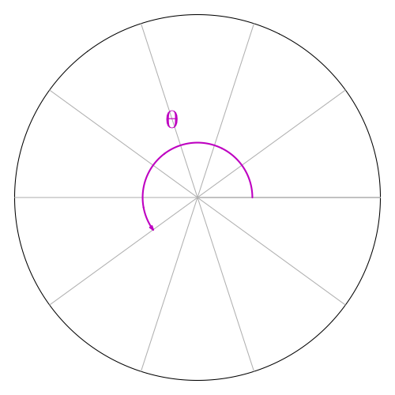

   - The angle is degrees.
   - The angle is $\pi\bigg/$ radians.
   - As a decimal approximation, the angle is radians.
   - The angle is $\bigg/$ turns.
   - As a decimal, the angle is turns.

### Circle 2

   - The circle below is cut into 20 congruent sectors. The central angle, $\phi$ (phi), subtends 12 of the sectors.

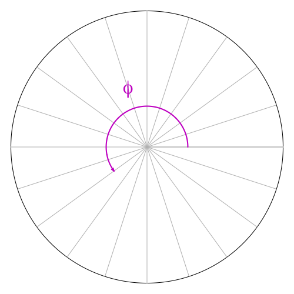

   - The angle is degrees.
   - The angle is $\pi\bigg/$ radians.
   - As a decimal approximation, the angle is radians.
   - The angle is $\bigg/$ turns.
   - As a decimal, the angle is turns.

### Circle 3

   - The circle below is cut into 12 congruent sectors. The central angle, $\omega$ (omega), subtends 1 of the sectors.

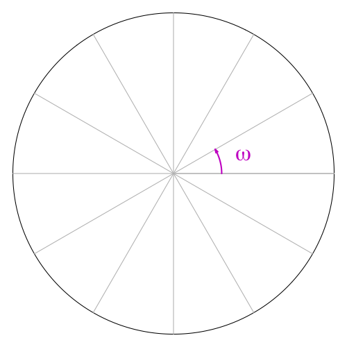

   - The angle is degrees.
   - The angle is $\pi\bigg/$ radians.
   - As a decimal approximation, the angle is radians.
   - The angle is $\bigg/$ turns.
   - As a decimal, the angle is turns.

### Circle 4

   - The circle below is cut into 18 congruent sectors. The central angle, $\psi$ (psi), subtends 13 of the sectors.

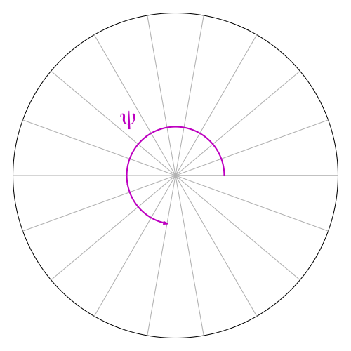

   - The angle is degrees.
   - The angle is $\pi\bigg/$ radians.
   - As a decimal approximation, the angle is radians.
   - The angle is $\bigg/$ turns.
   - As a decimal, the angle is turns.

### Circle 5

   - The circle below is cut into 24 congruent sectors. The central angle, $\beta$ (beta), subtends 21 of the sectors.

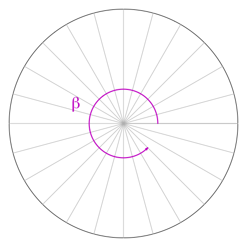

   - The angle is degrees.
   - The angle is $\pi\bigg/$ radians.
   - As a decimal approximation, the angle is radians.
   - The angle is $\bigg/$ turns.
   - As a decimal, the angle is turns.

#### Solution

#### Question

5. For each diagram below, a circle is sliced into congruent sectors. An angle, which subtends an integer count of the sectors, is indicated by an circular arc near the center of the circle. You will determine the measure of the angle using degrees, radians, and (fractions of) turns. All radian measures will be expressed in exact form, as a fraction of $\pi$. All fractions will be shown in [reduced form](https://en.wikipedia.org/wiki/Irreducible_fraction), using improper fractions instead of mixed numbers.

   Unlike temperature, where Fahrenheit and Celsius disagree on 0, all three units of angle measure agree on 0. All three measures grow linearly with arc length of a unit circle, so conversions are simple proportions, and the conversion factors can be expressed with the following equivalences.

   $$360^{\circ}~=~2\pi \text{ radians}~=~1\text{ turn}$$

   **Express the following angles using degrees, radians, and turns.**

### Circle 1

   - The circle below is cut into 20 congruent sectors. The central angle, $\theta$ (theta), subtends 19 of the sectors.

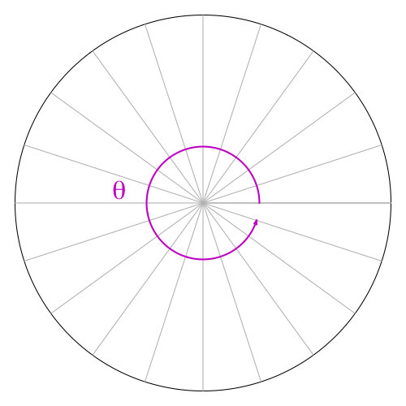

   - The angle is degrees.
   - The angle is $\pi\bigg/$ radians.
   - As a decimal approximation, the angle is radians.
   - The angle is $\bigg/$ turns.
   - As a decimal, the angle is turns.

### Circle 2

   - The circle below is cut into 18 congruent sectors. The central angle, $\phi$ (phi), subtends 16 of the sectors.

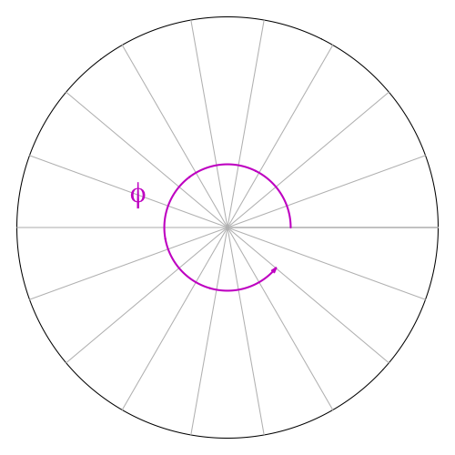

   - The angle is degrees.
   - The angle is $\pi\bigg/$ radians.
   - As a decimal approximation, the angle is radians.
   - The angle is $\bigg/$ turns.
   - As a decimal, the angle is turns.

### Circle 3

   - The circle below is cut into 4 congruent sectors. The central angle, $\omega$ (omega), subtends 3 of the sectors.

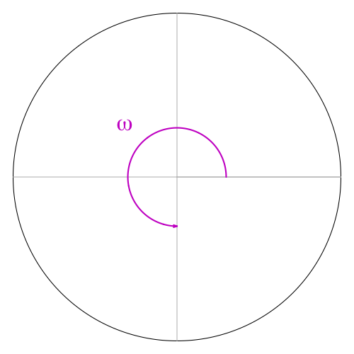

   - The angle is degrees.
   - The angle is $\pi\bigg/$ radians.
   - As a decimal approximation, the angle is radians.
   - The angle is $\bigg/$ turns.
   - As a decimal, the angle is turns.

### Circle 4

   - The circle below is cut into 24 congruent sectors. The central angle, $\psi$ (psi), subtends 10 of the sectors.

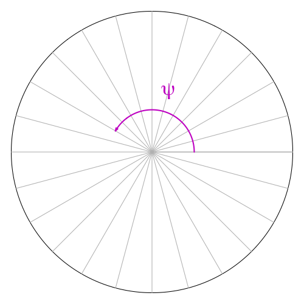

   - The angle is degrees.
   - The angle is $\pi\bigg/$ radians.
   - As a decimal approximation, the angle is radians.
   - The angle is $\bigg/$ turns.
   - As a decimal, the angle is turns.

### Circle 5

   - The circle below is cut into 8 congruent sectors. The central angle, $\beta$ (beta), subtends 7 of the sectors.

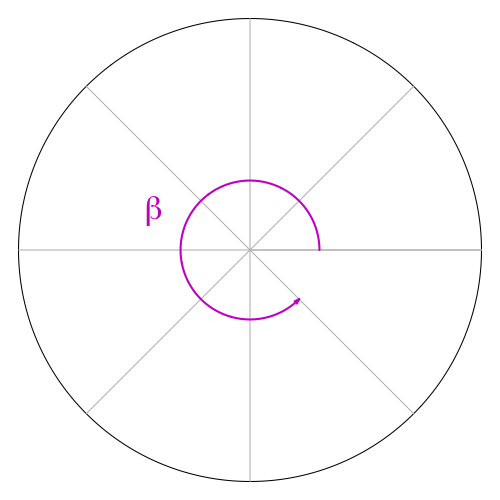

   - The angle is degrees.
   - The angle is $\pi\bigg/$ radians.
   - As a decimal approximation, the angle is radians.
   - The angle is $\bigg/$ turns.
   - As a decimal, the angle is turns.

#### Solution

#### Question

6. For each diagram below, a circle is sliced into congruent sectors. An angle, which subtends an integer count of the sectors, is indicated by an circular arc near the center of the circle. You will determine the measure of the angle using degrees, radians, and (fractions of) turns. All radian measures will be expressed in exact form, as a fraction of $\pi$. All fractions will be shown in [reduced form](https://en.wikipedia.org/wiki/Irreducible_fraction), using improper fractions instead of mixed numbers.

   Unlike temperature, where Fahrenheit and Celsius disagree on 0, all three units of angle measure agree on 0. All three measures grow linearly with arc length of a unit circle, so conversions are simple proportions, and the conversion factors can be expressed with the following equivalences.

   $$360^{\circ}~=~2\pi \text{ radians}~=~1\text{ turn}$$

   **Express the following angles using degrees, radians, and turns.**

### Circle 1

   - The circle below is cut into 4 congruent sectors. The central angle, $\theta$ (theta), subtends 1 of the sectors.

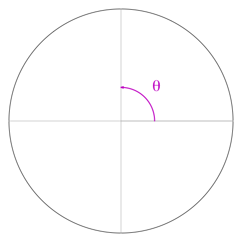

   - The angle is degrees.
   - The angle is $\pi\bigg/$ radians.
   - As a decimal approximation, the angle is radians.
   - The angle is $\bigg/$ turns.
   - As a decimal, the angle is turns.

### Circle 2

   - The circle below is cut into 10 congruent sectors. The central angle, $\phi$ (phi), subtends 2 of the sectors.

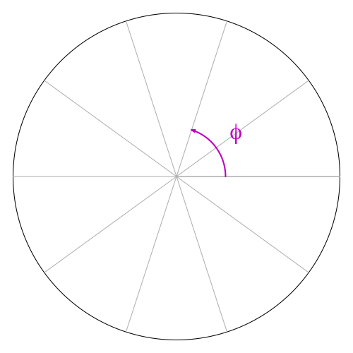

   - The angle is degrees.
   - The angle is $\pi\bigg/$ radians.
   - As a decimal approximation, the angle is radians.
   - The angle is $\bigg/$ turns.
   - As a decimal, the angle is turns.

### Circle 3

   - The circle below is cut into 24 congruent sectors. The central angle, $\omega$ (omega), subtends 2 of the sectors.

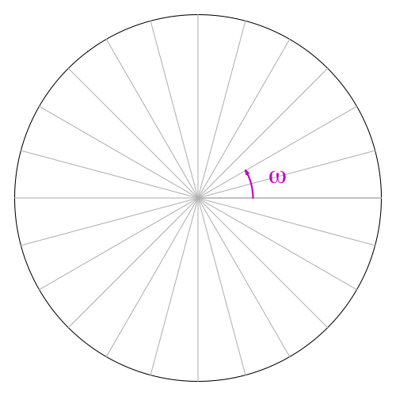

   - The angle is degrees.
   - The angle is $\pi\bigg/$ radians.
   - As a decimal approximation, the angle is radians.
   - The angle is $\bigg/$ turns.
   - As a decimal, the angle is turns.

### Circle 4

   - The circle below is cut into 20 congruent sectors. The central angle, $\psi$ (psi), subtends 19 of the sectors.

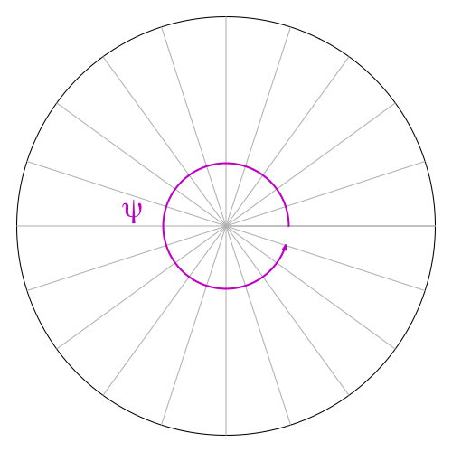

   - The angle is degrees.
   - The angle is $\pi\bigg/$ radians.
   - As a decimal approximation, the angle is radians.
   - The angle is $\bigg/$ turns.
   - As a decimal, the angle is turns.

### Circle 5

   - The circle below is cut into 6 congruent sectors. The central angle, $\beta$ (beta), subtends 1 of the sectors.

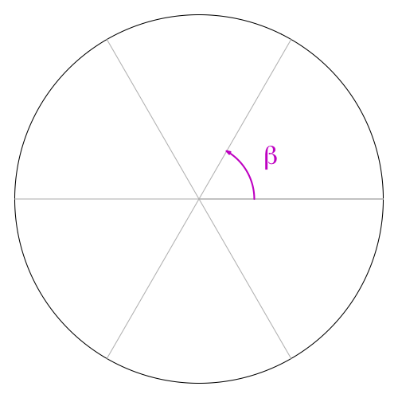

   - The angle is degrees.
   - The angle is $\pi\bigg/$ radians.
   - As a decimal approximation, the angle is radians.
   - The angle is $\bigg/$ turns.
   - As a decimal, the angle is turns.

#### Solution

#### Question

7. For each diagram below, a circle is sliced into congruent sectors. An angle, which subtends an integer count of the sectors, is indicated by an circular arc near the center of the circle. You will determine the measure of the angle using degrees, radians, and (fractions of) turns. All radian measures will be expressed in exact form, as a fraction of $\pi$. All fractions will be shown in [reduced form](https://en.wikipedia.org/wiki/Irreducible_fraction), using improper fractions instead of mixed numbers.

   Unlike temperature, where Fahrenheit and Celsius disagree on 0, all three units of angle measure agree on 0. All three measures grow linearly with arc length of a unit circle, so conversions are simple proportions, and the conversion factors can be expressed with the following equivalences.

   $$360^{\circ}~=~2\pi \text{ radians}~=~1\text{ turn}$$

   **Express the following angles using degrees, radians, and turns.**

### Circle 1

   - The circle below is cut into 24 congruent sectors. The central angle, $\theta$ (theta), subtends 21 of the sectors.

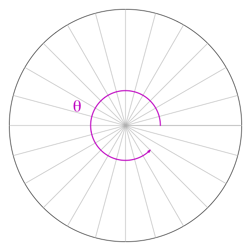

   - The angle is degrees.
   - The angle is $\pi\bigg/$ radians.
   - As a decimal approximation, the angle is radians.
   - The angle is $\bigg/$ turns.
   - As a decimal, the angle is turns.

### Circle 2

   - The circle below is cut into 10 congruent sectors. The central angle, $\phi$ (phi), subtends 1 of the sectors.

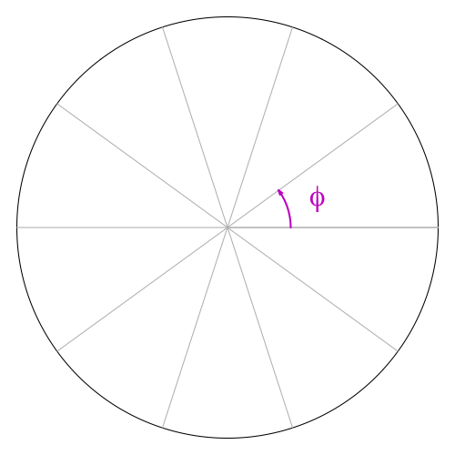

   - The angle is degrees.
   - The angle is $\pi\bigg/$ radians.
   - As a decimal approximation, the angle is radians.
   - The angle is $\bigg/$ turns.
   - As a decimal, the angle is turns.